← 使い方一覧に戻る

# 複数プラットフォームでの配信管理

## 概要

YouTube、Twitch、IRIAM など複数のプラットフォームで配信活動を行う場合の使い方です。

初回セットアップから基本的な使い方までをカバーします。 複数のプラットフォームでの配信に参加してくれる同一リスナーを統合管理し、プラットフォーム横断でデータを活用を目指します。

## 手順

### 1. 初回セットアップ

1. **アプリ起動**:
   - BondLog をブラウザで開き、ダッシュボードを表示。

[figure not shown]

   ダッシュボード

2. **プラットフォーム登録**:
   - 「📺 プラットフォーム」タブから「＋ プラットフォームを追加」ボタンを押し、各配信プラットフォーム(YouTube、Twitch など)を追加します

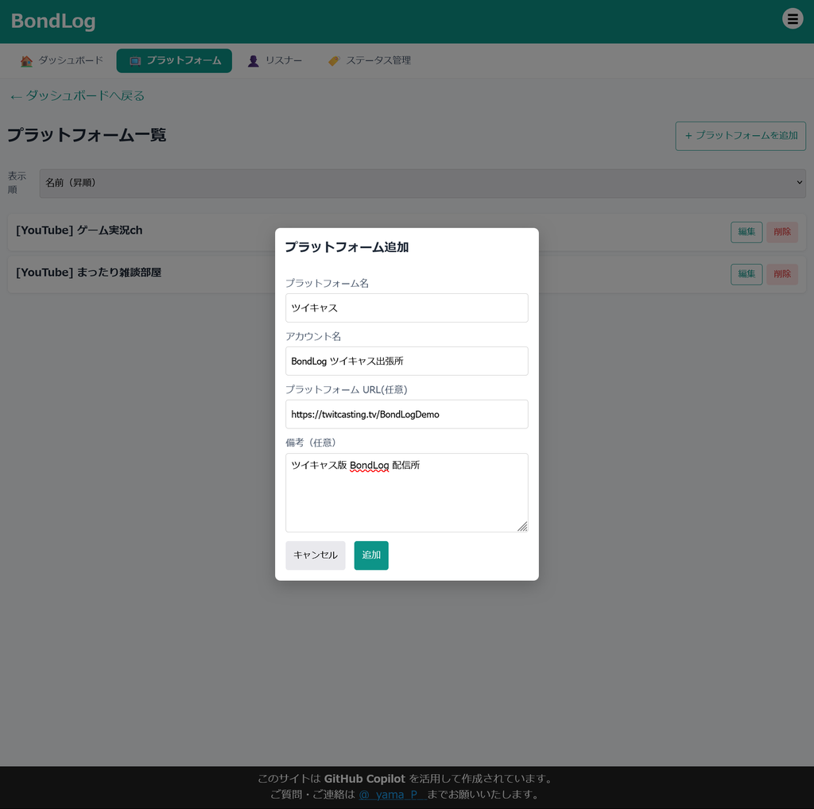

   プラットフォーム追加

   - **プラットフォーム** には候補が表示されるので候補から選ぶこともできます、自分で入力することもできます
   - **アカウント名** には自分のチャンネル名を入力します
   - **プラットフォームURL** には自分のチャンネルURLを入力します、入力しなくても登録できます - アプリ系の配信ではURLが設定されないこともあるので未入力で登録できます
   - **備考** にはメモを入力できます、入力しなくてもかまいません
   - **配信するプラットフォーム分、繰り返し登録します**

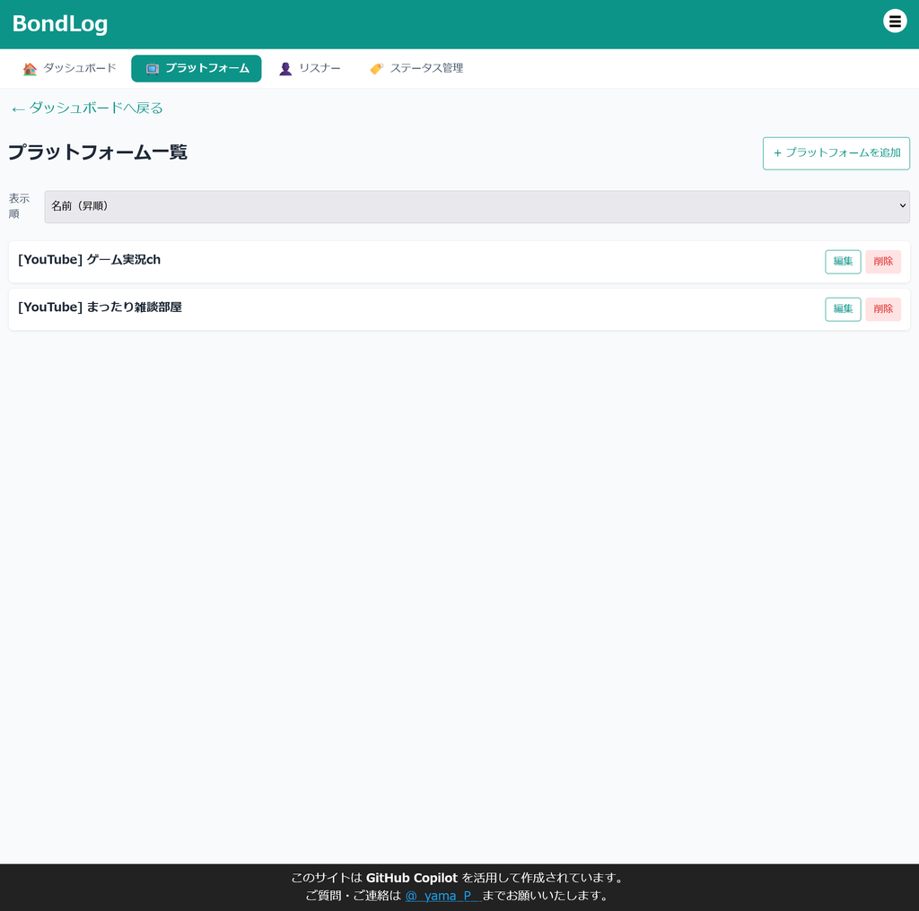

   プラットフォーム一覧

### 2. 基本的な使い方

1. **リスナー統合管理**:
   - 「👤 リスナー」タブから「＋ リスナーを追加」ボタンを押し新規リスナーを追加します

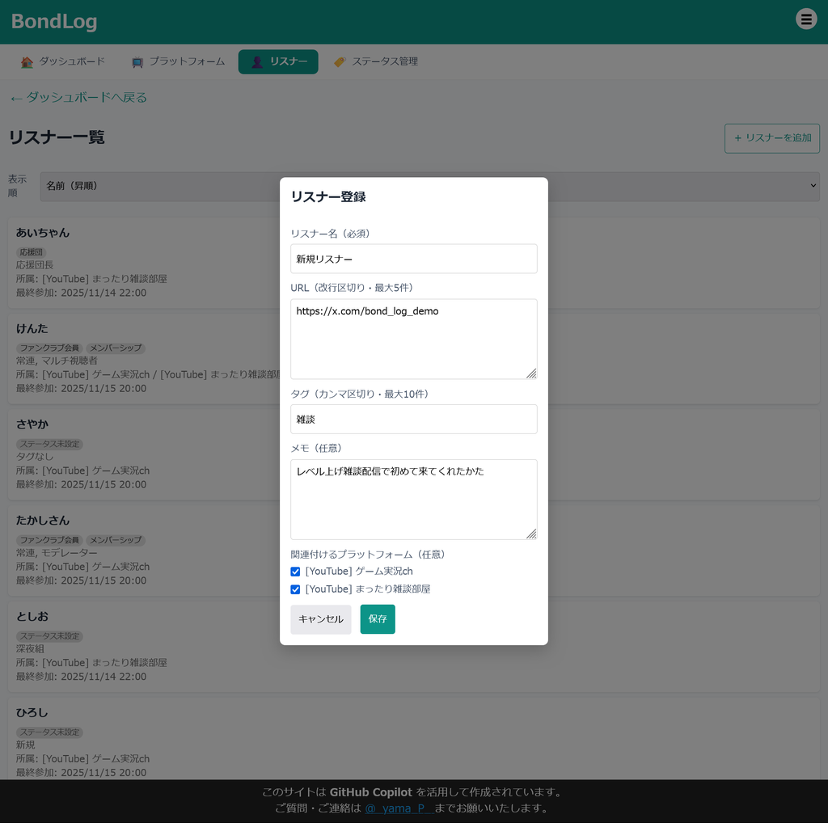

   リスナー追加

   - **リスナー名** にはリスナーの名前を入力します
     - ここに入力する名前が他の画面でも表示されます
     - 同じ名前の人がいる場合に区別できるよう登録することをおすすめします
   - **URL** にはリスナーが利用している SNS などのURLを入力します
     - あとから編集も可能なので、新規登録時には入力しなくてもかまいません
   - **タグ** でリスナーに任意のタグを付与することができます
     - たとえば `最古参`, `常連`, `歌枠好き` など、その人の属性を登録できます
     - あとから編集も可能なので、新規登録時には入力しなくてもかまいません
   - **メモ** は自由にメモを入力できます、入力しなくてもかまいません
   - **関連付けるプラットフォーム** には `1. 初回セットアップ` で登録したプラットフォームにチェックを入れます
     - 複数のプラットフォームで配信をしている場合、このリスナーが参加するプラットフォームを選択します
     - 異なるプラットフォームで同じ人物が参加している場合でも、1人のリスナーとして管理できます
2. **配信記録**:
   - 「📺 プラットフォーム」タブから登録したプラットフォームを選択し、プラットフォーム詳細画面へ移動します
   - プラットフォーム詳細画面で「＋ 配信を追加」ボタンを押します

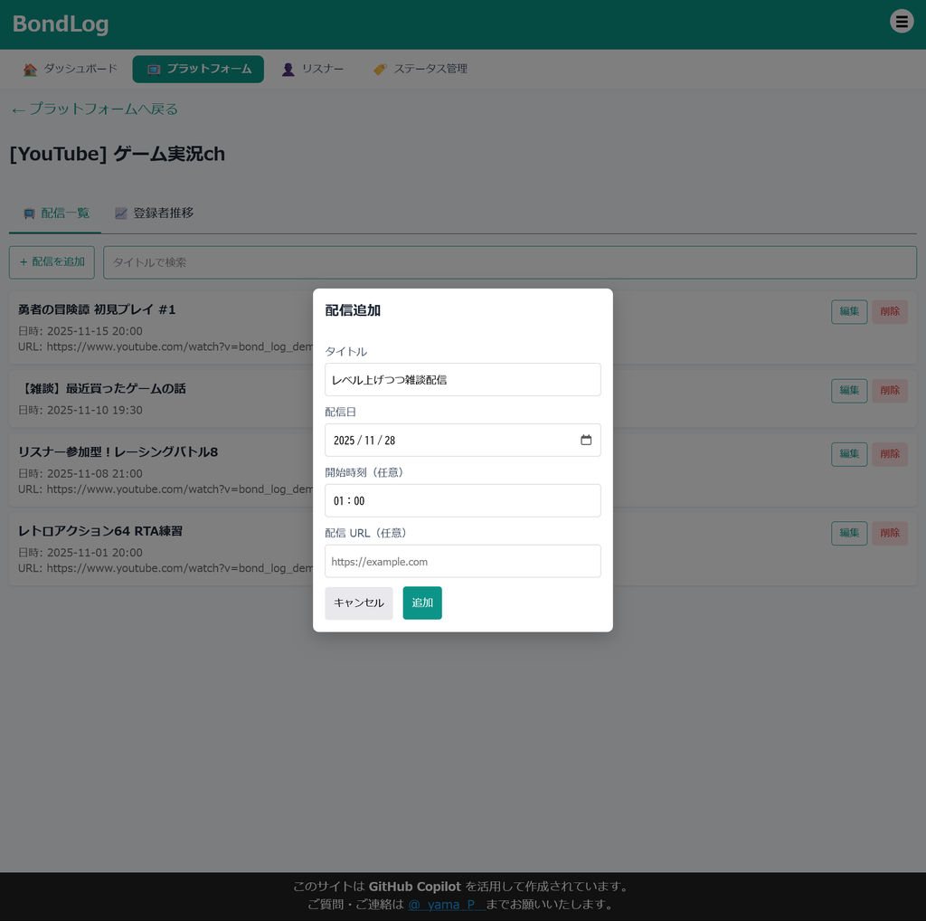

   配信追加

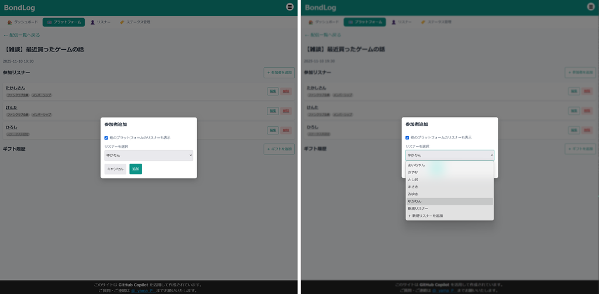

   参加者追加

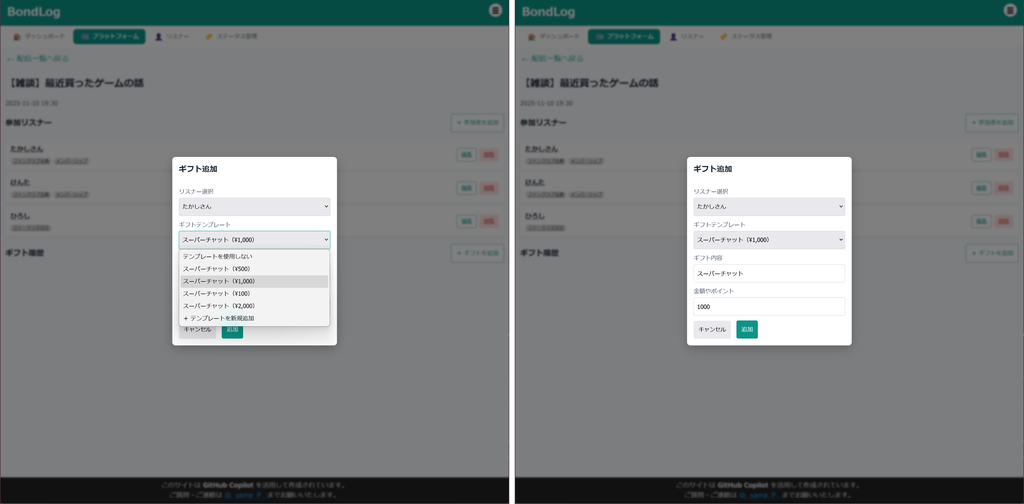

   ギフト追加

[figure not shown]

   登録者推移タブ

   - 「📺 プラットフォーム」タブから登録したプラットフォームを選択し、プラットフォーム詳細画面へ移動します
   - 「📈 登録者推移」タブを選択します
   - 「＋ 履歴を記録」ボタンを押します
   - **記録日** には記録日を入力します（カレンダーから選択）
   - **登録者数** には現在の登録者数を入力します
   - **メモ** には任意でメモを入力できます（例: 「新しい動画投稿後」など）
   - 入力後、「保存」ボタンを押して登録者数を記録します
   - 定期的に記録することで、ダッシュボードで推移グラフを確認できます
7. **データ保存**:
   - 定期的にメニューから「💾 エクスポート」を実行してバックアップします
   - **BondLog.html（オフライン版）をお使いの場合**: ダッシュボード上部の「BondLog 自動バックアップ」カードからフォルダを選択すると、30秒ごとに差分を検知してJSONファイルを自動保存できます（Chrome / Edge 等の Chromium 系ブラウザで利用可能）。詳しくは ユーザーガイド を参照してください。

## ポイント

- 同一人物のリスナーを統合することで、プラットフォームをまたいだ全体のつながりを把握できます。
- 登録者数を定期的に記録すると、ダッシュボードでプラットフォームごとの推移グラフが表示され、成長を比較できます。
- 「他のプラットフォームのリスナーも表示」機能を活用して、効率的に参加者を登録しましょう。

← 使い方一覧に戻る